# Reanalysis of Ratcliff and Rouder (1998) with Diffusion Model and LBA

Henrik Singmann

2019-10-07

This vignette provides the `R` scripts for a reanalysis of Experiment 1 of Ratcliff and Rouder (1998). In contrast to the original analysis, which used RT bins, we will employ trial-wise maximum likelihood estimation.

The code heavily uses [`dplyr`](https://cran.r-project.org/package=dplyr) ([vignette](https://CRAN.R-project.org/package=dplyr/vignettes/dplyr.html)), [`tidyr`](https://cran.r-project.org/package=tidyr) ([vignette](https://CRAN.R-project.org/package=tidyr/vignettes/tidy-data.html)), and [`purrr`](https://cran.r-project.org/package=purrr) for data handling and `lattice` (see `?Lattice`) and `latticeExtra` (specifically `as.layer`) for plotting. A throrough introduction to the former three packages is provided in [R for Data Science](http://r4ds.had.co.nz) by Wickham and Gorlemund, see especially Chapter 25.

# Description of the Experiment

In the experiment, three participants were asked to decide whether the overall brightness of pixel arrays displayed on a computer monitor was “high” or “low”. To this end, the number of white versus black pixels (i.e., the brightness `strength`) was manipulated in 33 levels from 0% white pixels (level 0) to 100% white pixels (level 32). In addition, instruction manipulated speed and accuracy between blocks. In total, each participant contributed around 4000 trials per instruction condition.

The experiment contained another manipulation, the distribution (or brightness `source`) from which the pixel array was drawn. One distribution mean was on the “high” brightness side and one distribution mean was on the “low” brightness side. However, as the distributions were unbounded and overlapping, the same strength level could come from either distribution. Participant also received feedback whether or not they had picked the correct distribution (e.g., for the middle strength level 16 probability of belonging to either source was 50%). We do not further consider this manipulation in the following, which seems to be in line with the analysis of Ratcliff and Rouder (1998).

# Descriptive data

As a first step, we load the data and then plot the probability with which each response (i.e., “dark” or “light”) is given as a function of strength and instruction condition. This clearly shows that there is a massive effect of strength on which response is given while at the same time the instruction only seems to have a minor effect and more on the extremes than in the middle.

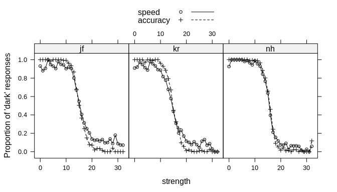

```r
require(rtdists)
require(dplyr)   # for data manipulations and looping
require(tidyr)   # for data manipulations
require(purrr)   # for data manipulations
require(lattice) # for plotting and corresponding themes
require(latticeExtra)
lattice.options(default.theme = standard.theme(color = FALSE))
lattice.options(default.args = list(as.table = TRUE))
options(digits = 3) # only three decimal digits
require(binom)  # for binomial confidence intervals

data(rr98)
rr98 <- rr98[!rr98$outlier,]  #remove outliers

# aggregate data for first plot:
agg_rr98 <- rr98  %>% group_by(id, instruction, strength) %>%
  summarise(prop = mean(response == "dark"), mean_rt = mean(rt), median_rt = mean(rt)) %>%
  ungroup()

xyplot(prop ~ strength|id, agg_rr98, group = instruction, type = "b",
       auto.key = list(lines = TRUE), ylab = "Proportion of 'dark' responses")
```

Next, we want to get an overview of the response time distributions. For this we look at the response times of the five quantiles (i.e., 0.1, 0.3, 0.5/median, 0.7, 0.9) across the strength manipulations. This time, we also separate the plots by condition as the speed condition resulted in, as expected, vastly shorter response times. These two plots reveal considerable differences between the two instruction conditions.

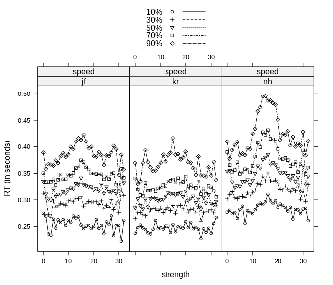

```r
quantiles <- c(0.1, 0.3, 0.5, 0.7, 0.9)
## aggregate data for quantile plot
quantiles_rr98 <- rr98  %>%
  group_by(id, instruction, strength) %>%
  nest() %>%
  mutate(quantiles = map(data, ~ as.data.frame(t(quantile(.x$rt, probs = quantiles))))) %>%
  unnest(quantiles) %>%
  gather("quantile", "rt",`10%`:`90%`) %>%
  arrange(id, instruction, strength)

xyplot(rt ~ strength|id + instruction, quantiles_rr98, group = quantile, type = "b",
       auto.key = list(lines = TRUE), ylab = "RT (in seconds)", subset = instruction == "speed")
```

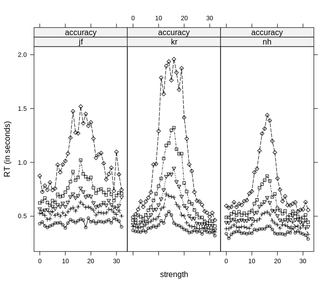

```r
xyplot(rt ~ strength|id + instruction, quantiles_rr98, group = quantile, type = "b",
       auto.key = FALSE, ylab = "RT (in seconds)", subset = instruction == "accuracy")
```

In the speed conditions, response times were, as expected, generally fast and there seemed to be hardly any effect of strength. Only for one participant, `nh`, we can see a small increase in RTs for the higher quantiles for strength values near the middle. In contrast, in the accuracy condition strength has a considerable effect on response times for all participants. Again, this increase was especially strong for the slower responses (i.e., the higher quantiles). For those we see a strong inverse u-shaped effect, symmetrically around the middle – where the probability for each response is 50% – with very high response times for strength values near the middle.

However, as this plot is getting a little bit messy, we now bin the strength levels to remove noise which should provide a clearer overview. For this, we will construct five separate strength bins with approximately equal response behavior and comparable numbers of trials. This is similar to what was done originally by Ratcliff and Rouder (1998). The next table shows the number of trials per participant, bin, and response.

```r
#bins <- c(-0.5, 5.5, 10.5, 13.5, 16.5, 19.5, 25.5, 32.5) # seven bins like RR98
bins <- c(-0.5, 10.5, 13.5, 16.5, 19.5, 32.5)
rr98$strength_bin <- cut(rr98$strength, breaks = bins, include.lowest = TRUE)
levels(rr98$strength_bin) <- as.character(1:7)

# aggregate data for response probability plot:
agg_rr98_bin <- rr98 %>%
  group_by(id, instruction, strength_bin) %>%
  summarise(n1 = n(),
            dark = sum(response == "dark"),
            light = sum(response == "light")) %>%
  ungroup() %>%
  mutate(prop = map2(dark, n1, ~ binom.confint(.x, .y, methods = "agresti-coull"))) %>%
  unnest(prop)


knitr::kable(
  rr98 %>% group_by(id, instruction, strength_bin, response) %>%
    summarise(n = n()) %>%
    spread(strength_bin, n)
)
```

| id | instruction | response | 1 | 2 | 3 | 4 | 5 |
| --- | --- | --- | --- | --- | --- | --- | --- |
| jf | speed | dark | 840 | 467 | 338 | 168 | 146 |
| jf | speed | light | 59 | 66 | 284 | 481 | 1060 |
| jf | accuracy | dark | 893 | 496 | 310 | 94 | 30 |
| jf | accuracy | light | 3 | 44 | 294 | 486 | 1176 |
| kr | speed | dark | 800 | 379 | 277 | 129 | 102 |
| kr | speed | light | 69 | 121 | 350 | 505 | 1064 |
| kr | accuracy | dark | 884 | 469 | 276 | 80 | 9 |
| kr | accuracy | light | 9 | 71 | 296 | 489 | 1202 |
| nh | speed | dark | 973 | 552 | 422 | 110 | 81 |
| nh | speed | light | 21 | 55 | 276 | 565 | 1290 |
| nh | accuracy | dark | 971 | 535 | 431 | 81 | 23 |
| nh | accuracy | light | 4 | 32 | 250 | 542 | 1318 |

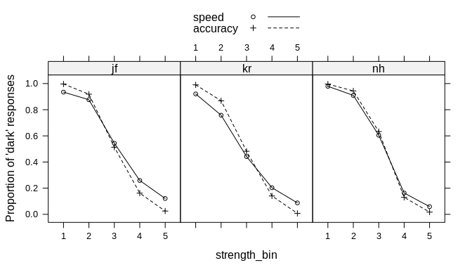

```r
xyplot(mean ~ strength_bin|id, agg_rr98_bin, group = instruction, type = "b",
       auto.key = list(lines = TRUE), ylab = "Proportion of 'dark' responses")
```

Now we also look again at the RT quantiles and see more clearly the symmetrical inverse u-shaped increase in RTs for the middle bins described above.

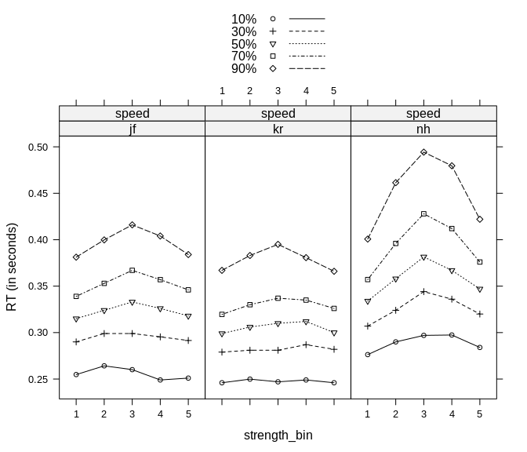

```r
## aggregate data for quantile plot
quantiles_rr98_bin <- rr98  %>%
  group_by(id, instruction, strength_bin) %>%
  nest() %>%
  mutate(quantiles = map(data, ~ as.data.frame(t(quantile(.x$rt, probs = quantiles))))) %>%
  unnest(quantiles) %>%
  gather("quantile", "rt",`10%`:`90%`) %>%
  arrange(id, instruction, strength_bin)

xyplot(rt ~ strength_bin|id + instruction, quantiles_rr98_bin, group = quantile, type = "b",
       auto.key = list(lines = TRUE), ylab = "RT (in seconds)", subset = instruction == "speed")
```

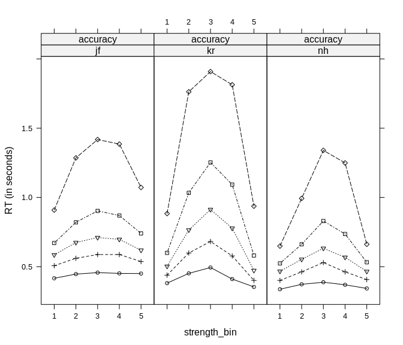

```r
xyplot(rt ~ strength_bin|id + instruction, quantiles_rr98_bin, group = quantile, type = "b",
       auto.key = FALSE, ylab = "RT (in seconds)", subset = instruction == "accuracy")
```

With this clear pattern we now take a look at the RT distributions separately for both responses to see if they are simply mirror images of each other or not. For this, we overlay the two RT quantile plots for all trials in which the responses was “dark” in black (there are more “dark” pixels for the bins on the left side of the plot) with the same plot in which the responses was “light” in grey (there are more “light” pixels for the bins on the right side of the plot).

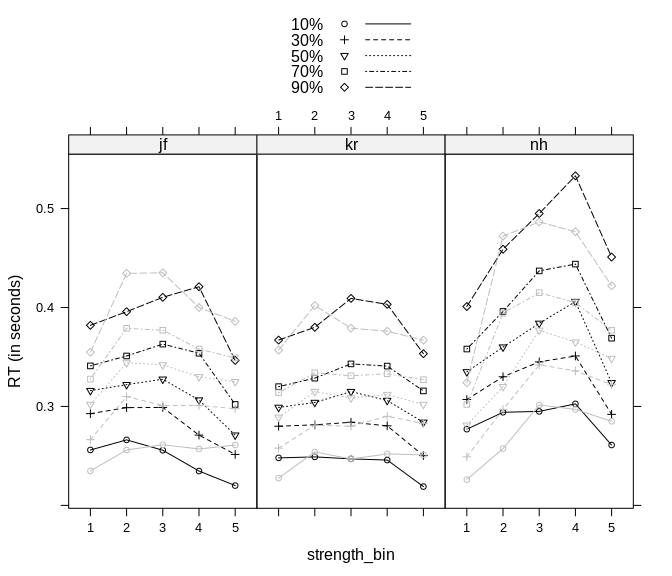

```r
agg2_rr98_response <- rr98  %>%
  group_by(id, instruction, strength_bin, response) %>%
  nest() %>%
  mutate(quantiles = map(data, ~ as.data.frame(t(quantile(.x$rt, probs = quantiles))))) %>%
  unnest(quantiles) %>%
  gather("quantile", "rt",`10%`:`90%`) %>%
  arrange(id, instruction, response, strength_bin)

p1 <- xyplot(rt ~ strength_bin|id, agg2_rr98_response, group = quantile, type = "b",
             auto.key = list(lines = TRUE), ylab = "RT (in seconds)",
             subset = instruction == "speed" & response == "dark", layout = c(3,1))
p2 <- xyplot(rt ~ strength_bin|id, agg2_rr98_response, group = quantile, type = "b",
             auto.key = list(lines = TRUE), ylab = "RT (in seconds)",
             subset = instruction == "speed" & response == "light", col = "grey")
p1 + as.layer(p2)
```

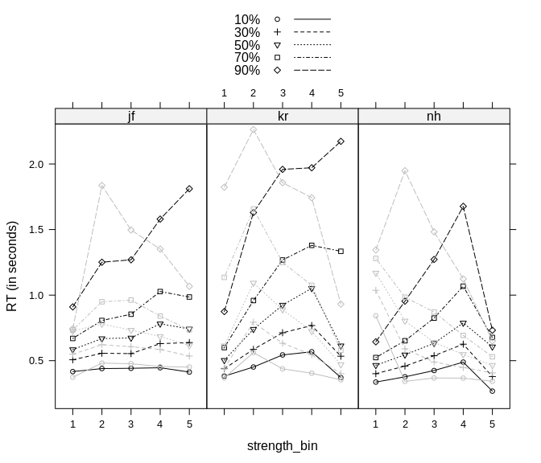

```r
p1 <- xyplot(rt ~ strength_bin|id, agg2_rr98_response, group = quantile, type = "b",
             auto.key = list(lines = TRUE), ylab = "RT (in seconds)",
             subset = instruction == "accuracy" & response == "dark", layout = c(3,1))
p2 <- xyplot(rt ~ strength_bin|id, agg2_rr98_response, group = quantile, type = "b",
             auto.key = list(lines = TRUE), ylab = "RT (in seconds)",
             subset = instruction == "accuracy" & response == "light", col = "grey")
p1 + as.layer(p2)
```

These two plots reveal an interesting pattern. In the speed condition (upper plot), we particularly see fast “errors” (i.e., responses to “dark” when there are more light pixels or the other way round). When “dark” is the more likely response (i.e. on the left side) the “light” responses in grey are faster and this is especially true for the lower quantiles. The opposite pattern seems to hold on the opposite side where “dark” responses in black are faster than “light” responses in grey. At intermediate bins the difference seems to be rather at the higher quantiles. This is particularly noticeable for participant `kr` for which for there seem to be slow “light”-“errors” just to the left to the middle bin and slow “right”-“errors” just to the right of the middle bin.

For the accuracy condition in the lower plot the pattern is noticeably different. First of all, there are only very few or no “error” responses in the extreme bins. Consequently, there does not seem to be any evidence for fast errors at the extremes (and also not at intermediate strength levels). However, we here more clearly see the slow errors at the intermediate bins. When “dark” is somewhat more probably (i.e., to the left of the middle) “light” responses are noticeably slower than “dark” responses. The same holds for “dark” responses if “light” is more probable. Importantly, this shows that the symmetrical inverse u-shaped increase for the middle bins described above is actually a consequence of a mixture of slow “errors”, two asymmetric increases for the two different responses.

# Diffusion Model Analysis

We will follow Ratcliff and Rouder (1998) and analyze the data with the diffusion model. For this, we will fit a separate model to each participant and instruction condition. To do so, we will first create a new data set we will use for fitting. This data set will be `nested` with one row for each combinations of the variables:

```r
d_nested <- rr98 %>%
  group_by(id, instruction) %>% # we loop across both, id and instruction
  nest()
d_nested
```

```
## # A tibble: 6 x 3
## # Groups:   id, instruction [6]
##   id    instruction            data
##   <fct> <fct>       <list<df[,11]>>
## 1 jf    accuracy       [3,826 × 11]
## 2 jf    speed          [3,909 × 11]
## 3 kr    accuracy       [3,785 × 11]
## 4 kr    speed          [3,796 × 11]
## 5 nh    speed          [4,345 × 11]
## 6 nh    accuracy       [4,187 × 11]
```

Like Ratcliff and Rouder we will fit the data to the strength bins instead of the full strength manipulation. We fit basically the full diffusion model (with the exception of $s_{t0}$) to each instruction condition which results in 10 parameters per participant and instruction condition:

- 5 drift rates $v$ (i.e., one per strength bin)
- 1 boundary separation $a$
- 1 non-decision time $t_0$
- 1 drift rate variability $s_v$
- 1 start point $z$ (for ease in interpretation we parameterize this as the *relative* start point so that values different from 0.5 indicate a bias towards one of the responses)
- 1 start point variability $s_z$

Like in Ratcliff and Rouder (1998), the two response boundaries are the two response options “dark” and “light”. To estimate the model we diverge from Ratcliff and Rouder and employ trial wise maximum likelihood estimation (i.e., no binning of responses).

For this, we simply need to have a wrapper function which returns us the negative summed log-likelihood of the data (i.e., RTs and corresponding responses) given a set of parameters. We need the negativ sum because most optimization function minimize whereas we want to obtain the maximum likelihood value. The following function for which we simply loop across drift rates will do so:

```r
# objective function for diffusion with 1 a. loops over drift to assign drift rates to strength
objective_diffusion_separate <- function(pars, rt, response, drift, ...) {
  non_v_pars <- grep("^v", names(pars), invert = TRUE, value = TRUE)
  base_par <- length(non_v_pars)  # number of non-drift parameters
  densities <- vector("numeric", length(rt))
  for (i in seq_along(levels(drift))) {
    densities[drift == levels(drift)[i]] <-
      ddiffusion(rt[drift == levels(drift)[i]], response=response[drift == levels(drift)[i]],
                 a=pars["a"], t0=pars["t0"],
                 sv=pars["sv"],
                 sz=if ("sz" %in% non_v_pars) pars["sz"] else 0.1,
                 z=if ("z" %in% non_v_pars) pars["z"]*pars["a"] else 0.5*pars["a"],
                 st0=if ("st0" %in% non_v_pars) pars["st0"] else 0,
                 v=pars[base_par+i])
  }
  if (any(densities == 0)) return(1e6)
  return(-sum(log(densities)))
}
```

Note that the function is written in such a way that we could easily fix certain parameters without the necessity to change it (using `if`-`then` on the parameters names passed via `pars`).

Additionally, we also need a function that generates a set of random starting values. And, as any random set of starting values may be impossible, another wrapper function that generates starting values until a set of valid starting values is found and then passes those to the optimization routine. As optimization routine we will be using `nlminb`. These functions are given next and are specified in a way that they will be usable for other model variants for this data (e.g., fixing parameters).

```r
# function that creates random start values, also
get_start <- function(base_par, n_drift = 5) {
  start1 <- c(
    a = runif(1, 0.5, 3),
    a_1 = runif(1, 0.5, 3),
    a_2 = runif(1, 0.5, 3),
    t0 = runif(1, 0, 0.5),
    z = runif(1, 0.4, 0.6),
    sz = runif(1, 0, 0.5),
    sv = runif(1, 0, 0.5),
    st0 = runif(1, 0, 0.5),
    d = rnorm(1, 0, 0.05)
  )
  start2 <- sort(rnorm(n_drift), decreasing = FALSE)
  names(start2) <- paste0("v_", seq_len(n_drift))
  c(start1[base_par], start2)
}

# function that tries different random start values until it works:
ensure_fit <-
  function(data, start_function, objective_function,
           base_pars, n_drift = 5, n_fits = 1,
           lower = c(rep(0, length(base_pars)), -Inf,
                     rep(-Inf,length(start_function(base_pars))-length(base_pars)))) {
    best_fit <- list(objective = 1e+06)
  for (i in seq_len(n_fits)) {
    start_ll <- 1e+06
    #browser()
    while(start_ll == 1e+06) {
      start <- start_function(base_pars, n_drift=n_drift)
      start_ll <- objective_function(start,
                                     rt = data$rt, response = data$response_num,
                                     drift = factor(data$strength_bin, seq_len(n_drift)),
                                     instruction = data$instruction)
    }
    cat("\nstart fitting.\n") # just for information to see if it is stuck

    fit <- nlminb(start, objective_function,
                  rt = data$rt, response = data$response_num,
                  drift = factor(data$strength_bin, seq_len(n_drift)),
                  instruction = data$instruction,
                  lower = lower)

    if (fit$objective < best_fit$objective) best_fit <- fit
  }
  out <- as.data.frame(t(unlist(best_fit[1:3])))
  colnames(out) <- sub("par.", "", colnames(out))
  out
}
```

With these functions in place, we now simply need to loop over participants and items to obtain the fit. The simplest way is perhaps to use the combination of `purrr:map` and `dplyr::mutate` as shown here:

```r
fit_diffusion <- d_nested %>%
  mutate(fit =
           map(data,
               ~ensure_fit(data = ., start_function = get_start,
                            objective_function = objective_diffusion_separate,
                            base_pars = c("a", "t0", "sv", "sz", "z")))) %>%
  unnest(fit)
```

On Unix-like systems (i.e., Linux and Mac) we can easily use the inbuild multicore functionality using `parallel::mclapply` to distribute fitting of the different parts across different cores:

```r
require(parallel)

fit_diffusion <- d_nested
fit_diffusion$fit <-
  mclapply(d_nested$data, function(x)
    ensure_fit(data = x, start_function = get_start,
               objective_function = objective_diffusion_separate,
               base_pars = c("a", "t0", "sv", "sz", "z")),
    mc.cores = 2)
fit_diffusion <- unnest(fit_diffusion, fit)
```

The following table gives the parameter values, the negative summed log-likelihoods (i.e., `objective`, where smaller is better), and the convergence code of the optimization algorithm (where 0 indicates no problem) obtained from this fit:

```r
fit_diffusion$data <- NULL
if (!("st0" %in% colnames(fit_diffusion))) fit_diffusion$st0 <- 0
if (!("z" %in% colnames(fit_diffusion))) fit_diffusion$z <- 0.5
if (!("sz" %in% colnames(fit_diffusion))) fit_diffusion$sz <- 0.1
knitr::kable(fit_diffusion)
```

| id | instruction | a | t0 | sv | sz | z | v_1 | v_2 | v_3 | v_4 | v_5 | objective | convergence | st0 |
| --- | --- | --- | --- | --- | --- | --- | --- | --- | --- | --- | --- | --- | --- | --- |
| jf | accuracy | 1.979 | 0.221 | 0.496 | 0.208 | 0.488 | -2.39 | -1.52 | -0.018 | 1.22 | 2.07 | 1301 | 0 | 0 |
| jf | speed | 0.877 | 0.195 | 0.000 | 0.222 | 0.468 | -2.92 | -2.28 | -0.075 | 1.83 | 2.94 | -3200 | 0 | 0 |
| kr | accuracy | 2.196 | 0.212 | 1.077 | 0.250 | 0.549 | -3.55 | -1.60 | -0.070 | 1.23 | 3.12 | 1228 | 0 | 0 |
| kr | speed | 0.819 | 0.196 | 0.196 | 0.216 | 0.475 | -2.99 | -1.66 | 0.550 | 2.18 | 3.25 | -3489 | 0 | 0 |
| nh | speed | 1.130 | 0.196 | 0.000 | 0.188 | 0.524 | -4.03 | -2.83 | -0.746 | 1.87 | 3.02 | -3318 | 0 | 0 |
| nh | accuracy | 1.843 | 0.227 | 1.001 | 0.547 | 0.519 | -3.80 | -2.35 | -0.620 | 1.67 | 3.38 | -245 | 0 | 0 |

## Graphical Model Fit

### Predicted Response Rates

To evaluate the fits graphically we first compare the actual response rates for the two responses with the predicted responses rates. The grey lines and points show the observed data and the error bars are binomial confidence intervals. The black lines and points show the predicted response rates.

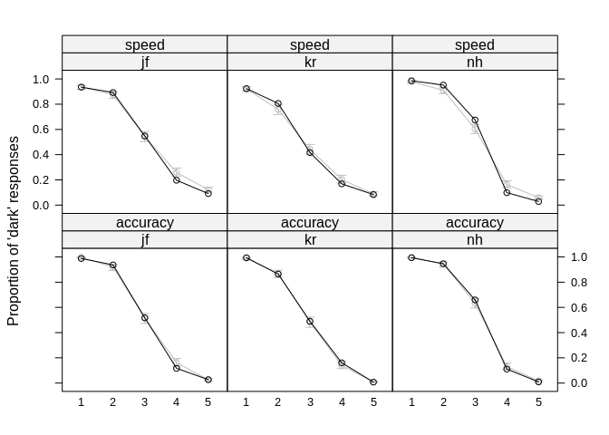

```r
# get predicted response proportions
pars_separate_l <- fit_diffusion %>% gather("strength_bin", "v", starts_with("v"))
pars_separate_l$strength_bin <- factor(substr(pars_separate_l$strength_bin, 3,3),
                                       levels = as.character(seq_len(length(bins)-1)))
#pars_separate_l <- inner_join(pars_separate_l, agg_rr98_bin)
pars_separate_l <- pars_separate_l  %>% group_by(id, instruction, strength_bin) %>%
  mutate(resp_prop = pdiffusion(rt=Inf, response="lower",
                                a=a, v=v, t0=t0, sz = sz, z=a*z, sv=sv, st0=st0))

p1 <- xyplot(mean ~ strength_bin|id + instruction, agg_rr98_bin, type = "b", auto.key =
               list(lines = TRUE), ylab = "Proportion of 'dark' responses", col = "grey")
p2 <- segplot(strength_bin ~ upper+lower|id + instruction, agg_rr98_bin,
              auto.key = list(lines = TRUE), ylab = "Proportion of 'dark' responses",
              col = "grey", horizontal = FALSE, segments.fun = panel.arrows,
              draw.bands = FALSE, angle = 90, length = 0.05, ends = "both")
p3 <- xyplot(resp_prop ~ strength_bin|id + instruction, pars_separate_l, type = "b",
             auto.key = list(lines = TRUE), ylab = "Proportion of 'dark' responses",
             col = "black")
p2 + as.layer(p1) + as.layer(p3)
```

This figure show that overall the model can predict the actual response rates very accurately. There are only a few minor deviations.

### Predicted Median RTs

Next we compare the central tendency of the RTs with the prediction. For this we evaluate the CDF at the quantiles of the predicted response proportions. Again, the data is shown in grey (and error bars show the standard errors of the median) and the predicted RTs in black. We first show the predictions for the speed condition, separated by response.

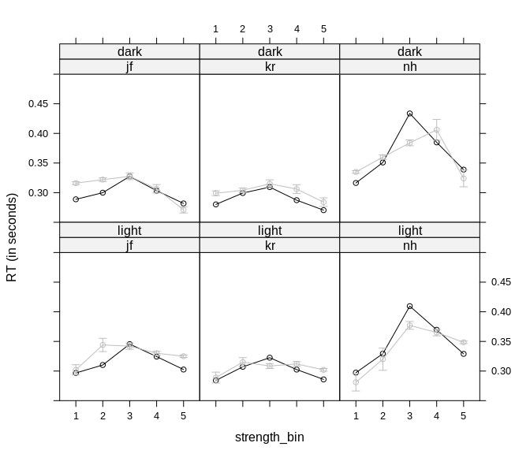

```r
# get predicted quantiles (uses predicted response proportions)
separate_pred_dark <- pars_separate_l %>% do(as.data.frame(t(
  qdiffusion(quantiles*.$resp_prop, response="lower",
             a=.$a, v=.$v, t0=.$t0, sz = .$sz, z = .$z*.$a, sv=.$sv, st0=.$st0)))) %>%
  ungroup() %>% gather("quantiles", "dark", V1:V5)
separate_pred_light <- pars_separate_l %>% do(as.data.frame(t(
  qdiffusion(quantiles*(1-.$resp_prop), response="upper",
             a=.$a, v=.$v, t0=.$t0, sz = .$sz, z = .$z*.$a, sv=.$sv, st0=.$st0)))) %>%
  ungroup() %>% gather("quantiles", "light", V1:V5)

#separate_pred_light %>% filter(is.na(light))
separate_pred <- inner_join(separate_pred_dark, separate_pred_light)
separate_pred$quantiles <- factor(separate_pred$quantiles,
                                  levels = c("V5", "V4", "V3", "V2", "V1"),
                                  labels = c("90%", "70%", "50%", "30%", "10%"))
separate_pred <- separate_pred %>% gather("response", "rt", dark, light)

# get SE for observed quantiles
agg2_rr98_response_se <- rr98  %>% group_by(id, instruction, strength_bin, response) %>%
  summarise(se_median = sqrt(pi/2)*(sd(rt)/sqrt(n()))) %>%
  ungroup()

# calculate error bars for quantiles.
agg2_rr98_response <- left_join(agg2_rr98_response, agg2_rr98_response_se)
agg2_rr98_response <- agg2_rr98_response %>%
  mutate(lower = rt-se_median, upper = rt+se_median)


p1 <- xyplot(rt ~ strength_bin|id+response, agg2_rr98_response, type = "b",
             auto.key = list(lines = TRUE), ylab = "RT (in seconds)",
             subset = instruction == "speed" & quantile == "50%",
             layout = c(3,2), col = "grey")
p1e <- segplot(strength_bin ~ upper+lower|id+response, agg2_rr98_response,
               auto.key = list(lines = TRUE), ylab = "Proportion of 'dark' responses",
               col = "grey", horizontal = FALSE, segments.fun = panel.arrows,
               draw.bands = FALSE, angle = 90, length = 0.05, ends = "both",
               subset = instruction == "speed" & quantile == "50%", layout = c(3,2))
p2 <- xyplot(rt ~ strength_bin|id + response, separate_pred, type = "b",
             auto.key = list(lines = TRUE), ylab = "RT (in seconds)",
             subset = instruction == "speed" & quantiles == "50%",
             scales = list(y = list(limits = c(0.25, 0.5))))
p2 + as.layer(p1) + as.layer(p1e)
```

Again, the model seems to be overall able to describe the general pattern quite well. However, there are some visible misfits for participants `jf` and `nh`.

Next shows the same plot for the accuracy condition. Here we again see that the model is able to predict the pattern in the data quite well. While there also seems to be quite some misfit for participant `nh` this only appears in conditions with very little trials as indicated by the large error bars.

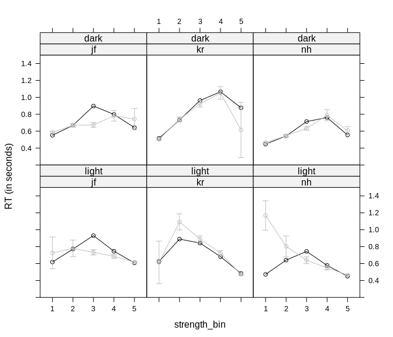

```r
p1 <- xyplot(rt ~ strength_bin|id+response, agg2_rr98_response, type = "b",
             auto.key = list(lines = TRUE), ylab = "RT (in seconds)",
             subset = instruction == "accuracy" & quantile == "50%",
             layout = c(3,2), col = "grey")
p1e <- segplot(strength_bin ~ upper+lower|id+response, agg2_rr98_response,
               auto.key = list(lines = TRUE), ylab = "Proportion of 'dark' responses",
               col = "grey", horizontal = FALSE, segments.fun = panel.arrows,
               draw.bands = FALSE, angle = 90, length = 0.05, ends = "both",
               subset = instruction == "accuracy" & quantile == "50%", layout = c(3,2))
p2 <- xyplot(rt ~ strength_bin|id + response, separate_pred, type = "b",
             auto.key = list(lines = TRUE), ylab = "RT (in seconds)",
             subset = instruction == "accuracy" & quantiles == "50%",
             scales = list(y = list(limits = c(0.2, 1.5))))
p2 + as.layer(p1) + as.layer(p1e)
```

### All quantiles

Next, we investigate the full RT distribution by comparing observed and predicted quantiles. The observed quantiles are again displayed in grey and the predictions in black. The first plot shows the sped condition separated by response.

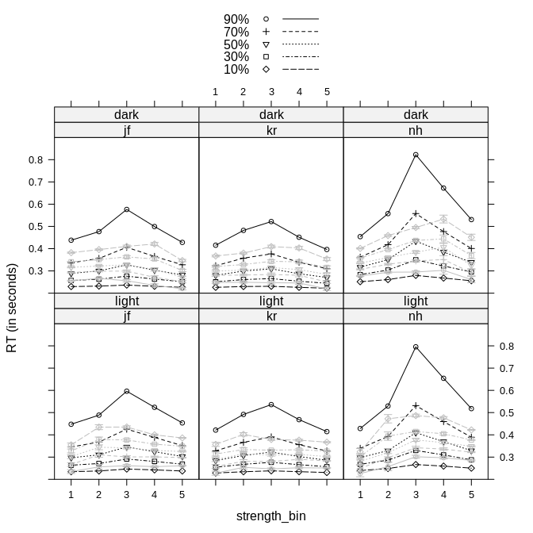

```r
p1 <- xyplot(rt ~ strength_bin|id+response, agg2_rr98_response, group = quantile, type = "b",
             auto.key = list(lines = TRUE), ylab = "RT (in seconds)",
             subset = instruction == "speed", layout = c(3,2), col = "grey")
p1e <- segplot(strength_bin ~ upper+lower|id+response, agg2_rr98_response,
               auto.key = list(lines = TRUE), ylab = "Proportion of 'dark' responses",
               col = "grey", horizontal = FALSE, segments.fun = panel.arrows,
               draw.bands = FALSE, angle = 90, length = 0.05, ends = "both",
               subset = instruction == "speed")
p2 <- xyplot(rt ~ strength_bin|id + response, separate_pred, group = quantiles, type = "b",
             auto.key = list(lines = TRUE), ylab = "RT (in seconds)",
             subset = instruction == "speed", scales = list(y = list(limits = c(0.2, 0.9))))
p2 + as.layer(p1) + as.layer(p1e)
```

This plots shows some clear misfits for the diffusion model, particularly in the upper quantiles. But there are also misfits in the lower quantiles.

The next plot shows the accuracy condition separated by response. Here it appears that the diffusion model provides an overall better account. However, it is important to consider the different y-axis scaling of both plots.

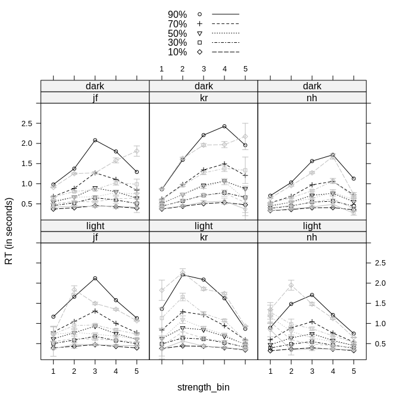

```r
p1 <- xyplot(rt ~ strength_bin|id+response, agg2_rr98_response, group = quantile, type = "b",
             auto.key = list(lines = TRUE), ylab = "RT (in seconds)",
             subset = instruction == "accuracy", layout = c(3,2), col = "grey")
p1e <- segplot(strength_bin ~ upper+lower|id+response, agg2_rr98_response,
               auto.key = list(lines = TRUE), ylab = "Proportion of 'dark' responses",
               col = "grey", horizontal = FALSE, segments.fun = panel.arrows,
               draw.bands = FALSE, angle = 90, length = 0.05, ends = "both",
               subset = instruction == "accuracy")
p2 <- xyplot(rt ~ strength_bin|id + response, separate_pred, group = quantiles, type = "b",
             auto.key = list(lines = TRUE), ylab = "RT (in seconds)",
             subset = instruction == "accuracy", scales = list(y = list(limits = c(0.1, 3.0))))
p2 + as.layer(p1) + as.layer(p1e)
```

Overall the diffusion model provides a good account of the data. Only when considering all quantiles we see some clear misfits. Nevertheless, the general trends in the data are well recovered, the only exceptions here are conditions with very low numbers of trials.

# LBA analysis

Next, we fit the LBA model to the data. For this, we use an LBA model with the same number of parameters. To make the model identifiable, we fix the sum of the drift rates to 1. Specifically, the model has the following 10 parameters per participant and instruction condition:

- 5 drift rates $v$ (i.e., one per strength bin)
- 2 response thresholds $A$ (i.e., one for each accumulator)
- 1 non-decision time $t_0$ (i.e., one per participant)
- 1 drift rate variability $s_v$
- 1 starting points $b$ (parameterized as an increment to the max value of the two $A$)

To fit the model we need an objective function wrapping the LBA PDF and a new function for generating the correct starting values.

```r
# objective function for diffusion with 1 a. loops over drift to assign drift rates to strength
objective_lba_separate <- function(pars, rt, response, drift, ...) {
  non_v_pars <- grep("^v", names(pars), invert = TRUE, value = TRUE)
  base_par <- length(non_v_pars)  # number of non-drift parameters
  densities <- vector("numeric", length(rt))
  for (i in seq_along(levels(drift))) {
    if (sum(drift == levels(drift)[i]) == 0) next
    densities[drift == levels(drift)[i]] <- dLBA(
      rt[drift == levels(drift)[i]],
      response=response[drift == levels(drift)[i]],
      A = list(pars["a_1"], pars["a_2"]),
      b = max(pars["a_1"], pars["a_2"])+pars["b"],
      t0 = pars["t0"],
      mean_v = c(pars[i], 1-pars[i]),
      sd_v = pars["sv"], silent=TRUE)
  }
  if (any(densities == 0)) return(1e6)
  return(-sum(log(densities)))
}

# function that creates random start values
get_start_lba <- function(base_par, n_drift = 10) {
  start1 <- c(
    a = runif(1, 0.5, 3),
    a_1 = runif(1, 0.5, 3),
    a_2 = runif(1, 0.5, 3),
    t0 = runif(1, 0, 0.5),
    b = runif(1, 0, 0.5),
    sv = runif(1, 0.5, 1.5),
    st0 = runif(1, 0, 0.5)
  )
  start2 <- sort(rnorm(n_drift), decreasing = FALSE)
  names(start2) <- paste0("v_", seq_len(n_drift))
  c(start2, start1[base_par])
}
```

With this, we simply need to loop across participants and instructions to estimate the LBA. Again, we need to run several fitting runs to reach the maximum likelihood estimate (i.e., the global optimum).

```r
fit_lba <- d_nested %>%
  mutate(fit =
           map(data,
               ~ensure_fit(data = ., start_function = get_start_lba,
                      objective_function = objective_lba_separate,
                      base_pars = c("a_1", "a_2", "t0", "b", "sv"),
                      lower = c(rep(-Inf, 5), rep(0, 5)),
                      n_drift = 5, n_fits = 10))) %>%
  unnest(fit)
```

Again, on Unix-like systems (i.e., Linux and Mac) we can use multicore using `parallel::mclapply`:

```r
require(parallel)

fit_lba <- d_nested
fit_lba$fit <-
  mclapply(d_nested$data, function(x)
    ensure_fit(data = x, start_function = get_start_lba,
                      objective_function = objective_lba_separate,
                      base_pars = c("a_1", "a_2", "t0", "b", "sv"),
                      lower = c(rep(-Inf, 5), rep(0, 5)),
                      n_drift = 5, n_fits = 10),
    mc.cores = 2)
fit_lba <- unnest(fit_lba, fit)
```

The following table gives the parameters and the negative summed log-likelihoods obtained from the LBA fit (with $b$ already correctly transformed by the maximum $A$). Note that some of the parameters might differ slightly for for id = `kr` and instruction = `accuracy` although the value of the objective function is identical to the reported one. This suggests that the likelihood surface is either quite shallow near the MLE or there are at least two peaks in the likelihood surface with a similar maximum. The fact that the convergence code for this data set is 1 instead of 0 also suggests some problems in finding the gloval optimum. In any case, running the optimization multiple times and comparing the results should reveal such problems.

```r
knitr::kable(fit_lba)
```

| id | instruction | v_1 | v_2 | v_3 | v_4 | v_5 | a_1 | a_2 | t0 | b | sv | objective | convergence |
| --- | --- | --- | --- | --- | --- | --- | --- | --- | --- | --- | --- | --- | --- |
| jf | accuracy | 0.964 | 0.793 | 0.508 | 0.259 | 0.096 | 0.359 | 0.331 | 0.049 | 0.327 | 0.293 | 1171 | 0 |
| jf | speed | 0.586 | 0.565 | 0.494 | 0.439 | 0.406 | 0.084 | 0.067 | 0.014 | 0.133 | 0.100 | -3855 | 0 |
| kr | accuracy | 3.580 | 2.101 | 0.526 | -0.812 | -2.413 | 0.596 | 0.885 | 0.107 | 0.863 | 1.383 | 1358 | 1 |
| kr | speed | 0.619 | 0.563 | 0.471 | 0.411 | 0.368 | 0.075 | 0.066 | 0.083 | 0.096 | 0.136 | -4033 | 0 |
| nh | speed | 0.678 | 0.613 | 0.529 | 0.425 | 0.378 | 0.065 | 0.076 | 0.038 | 0.155 | 0.123 | -4235 | 0 |
| nh | accuracy | 1.448 | 1.100 | 0.644 | 0.022 | -0.381 | 0.387 | 0.405 | 0.144 | 0.238 | 0.456 | -227 | 0 |

The negtaive log-likelihood (column `objective`) shows that the LBA provides a better account for four of the six data sets (because it is the negative log-likelihood, smaller is better). The diffusion model only provides a better account for the `kr` and `nh` accuracy conditions. In terms of the parameter estimates we see a pattern similar as the one for the diffusion model:

- Instruction shows the expected effect on $b$.
- Instruction also shows an effect on $A$, which is also larger in the accuracy compared to the speed condition.
- Instruction seems to have a small effect on $t_0$ in the same direction.
- Instruction also affected $s_v$ in the same direction.
- Instruction also affected $v$ which seemed to be more extreme in the accuracy compared to the speed condition.

## Graphical Model Fit

The fact that the LBA provides a slightly better fit is also visible in the graphical fit assessment.

### Predicted Response Rates

We again first consider the predicted response rates (in black) and they are also highly accurate.

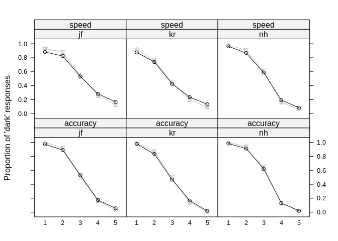

```r
# get predicted response proportions
lba_pars_separate_l <- fit_lba %>% gather("strength_bin", "v", starts_with("v"))
lba_pars_separate_l$strength_bin <- factor(substr(lba_pars_separate_l$strength_bin, 3,3),
                                       levels = as.character(seq_len(length(bins)-1)))
#pars_separate_l <- inner_join(pars_separate_l, agg_rr98_bin)
lba_pars_separate_l <- lba_pars_separate_l  %>% group_by(id, instruction, strength_bin) %>%
  mutate(resp_prop = pLBA(rt=Inf, response=1, A=list(a_1, a_2), sd_v=sv,
                          mean_v=c(v, 1-v), t0=t0, b=max(a_1, a_2)+b, silent=TRUE))

p1 <- xyplot(mean ~ strength_bin|id + instruction, agg_rr98_bin, type = "b", auto.key =
               list(lines = TRUE), ylab = "Proportion of 'dark' responses", col = "grey")
p2 <- segplot(strength_bin ~ upper+lower|id + instruction, agg_rr98_bin,
              auto.key = list(lines = TRUE), ylab = "Proportion of 'dark' responses",
              col = "grey", horizontal = FALSE, segments.fun = panel.arrows,
              draw.bands = FALSE, angle = 90, length = 0.05, ends = "both")
p3 <- xyplot(resp_prop ~ strength_bin|id + instruction, lba_pars_separate_l, type = "b",
             auto.key = list(lines = TRUE), ylab = "Proportion of 'dark' responses",
             col = "black")
p2 + as.layer(p1) + as.layer(p3)
```

### Predicted Median RTs

Again, the data is shown in grey (and error bars show the standard errors of the median) and the predicted RTs in black. We first show the predictions for the speed condition, separated by response.

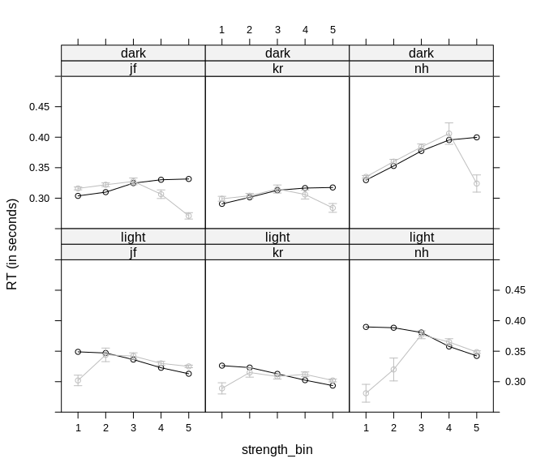

```r
# get predicted quantiles (uses predicted response proportions)
lba_separate_pred_dark <- lba_pars_separate_l %>% do(as.data.frame(t(
  qLBA(quantiles*.$resp_prop, response=1, A=list(.$a_1, .$a_2), sd_v=.$sv,
       mean_v=c(.$v, 1-.$v), t0=.$t0, b=max(.$a_1, .$a_2)+.$b, silent=TRUE)))) %>%
  ungroup() %>% gather("quantiles", "dark", V1:V5)
lba_separate_pred_light <- lba_pars_separate_l %>% do(as.data.frame(t(
  qLBA(quantiles*(1-.$resp_prop), response=2, A=list(.$a_1, .$a_2), sd_v=.$sv,
       mean_v=c(.$v, 1-.$v), t0=.$t0, b=max(.$a_1, .$a_2)+.$b, silent=TRUE)))) %>%
  ungroup() %>% gather("quantiles", "light", V1:V5)

#separate_pred_light %>% filter(is.na(light))
lba_separate_pred <- inner_join(lba_separate_pred_dark, lba_separate_pred_light)
lba_separate_pred$quantiles <- factor(lba_separate_pred$quantiles,
                                  levels = c("V5", "V4", "V3", "V2", "V1"),
                                  labels = c("90%", "70%", "50%", "30%", "10%"))
lba_separate_pred <- lba_separate_pred %>% gather("response", "rt", dark, light)

p1 <- xyplot(rt ~ strength_bin|id+response, agg2_rr98_response, type = "b",
             auto.key = list(lines = TRUE), ylab = "RT (in seconds)",
             subset = instruction == "speed" & quantile == "50%",
             layout = c(3,2), col = "grey")
p1e <- segplot(strength_bin ~ upper+lower|id+response, agg2_rr98_response,
               auto.key = list(lines = TRUE), ylab = "Proportion of 'dark' responses",
               col = "grey", horizontal = FALSE, segments.fun = panel.arrows,
               draw.bands = FALSE, angle = 90, length = 0.05, ends = "both",
               subset = instruction == "speed" & quantile == "50%", layout = c(3,2))
p2 <- xyplot(rt ~ strength_bin|id + response, lba_separate_pred, type = "b",
             auto.key = list(lines = TRUE), ylab = "RT (in seconds)",
             subset = instruction == "speed" & quantiles == "50%",
             scales = list(y = list(limits = c(0.25, 0.5))))
p2 + as.layer(p1) + as.layer(p1e)
```

Next shows the same plot for the accuracy condition.

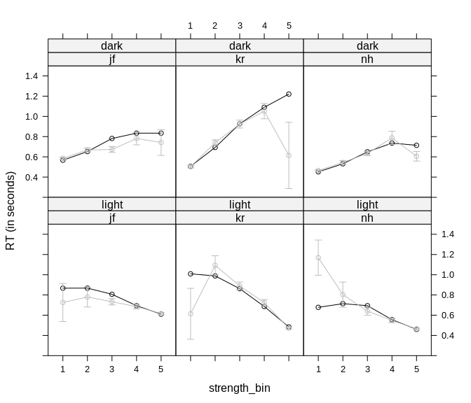

```r
p1 <- xyplot(rt ~ strength_bin|id+response, agg2_rr98_response, type = "b",
             auto.key = list(lines = TRUE), ylab = "RT (in seconds)",
             subset = instruction == "accuracy" & quantile == "50%",
             layout = c(3,2), col = "grey")
p1e <- segplot(strength_bin ~ upper+lower|id+response, agg2_rr98_response,
               auto.key = list(lines = TRUE), ylab = "Proportion of 'dark' responses",
               col = "grey", horizontal = FALSE, segments.fun = panel.arrows,
               draw.bands = FALSE, angle = 90, length = 0.05, ends = "both",
               subset = instruction == "accuracy" & quantile == "50%", layout = c(3,2))
p2 <- xyplot(rt ~ strength_bin|id + response, lba_separate_pred, type = "b",
             auto.key = list(lines = TRUE), ylab = "RT (in seconds)",
             subset = instruction == "accuracy" & quantiles == "50%",
             scales = list(y = list(limits = c(0.2, 1.5))))
p2 + as.layer(p1) + as.layer(p1e)
```

Overall the LBA is able to describe the central tendency relatively well. The only considerable misfit is evident at the extreme bins with few responses (i.e., large error bars).

### All quantiles

Next, we investigate the full RT distribution by comparing observed and predicted quantiles. The observed quantiles are again displayed in grey and the predictions in black. The first plot shows the speed condition separated by response.

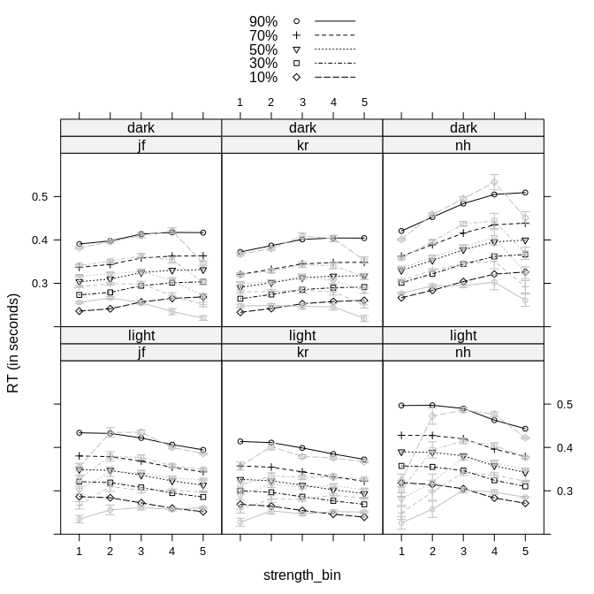

```r
p1 <- xyplot(rt ~ strength_bin|id+response, agg2_rr98_response, group = quantile, type = "b",
             auto.key = list(lines = TRUE), ylab = "RT (in seconds)",
             subset = instruction == "speed", layout = c(3,2), col = "grey")
p1e <- segplot(strength_bin ~ upper+lower|id+response, agg2_rr98_response,
               auto.key = list(lines = TRUE), ylab = "Proportion of 'dark' responses",
               col = "grey", horizontal = FALSE, segments.fun = panel.arrows,
               draw.bands = FALSE, angle = 90, length = 0.05, ends = "both",
               subset = instruction == "speed")
p2 <- xyplot(rt ~ strength_bin|id + response, lba_separate_pred, group = quantiles, type = "b",
             auto.key = list(lines = TRUE), ylab = "RT (in seconds)",
             subset = instruction == "speed", scales = list(y = list(limits = c(0.2, 0.6))))
p2 + as.layer(p1) + as.layer(p1e)
```

The next plot shows the accuracy condition separated by response.

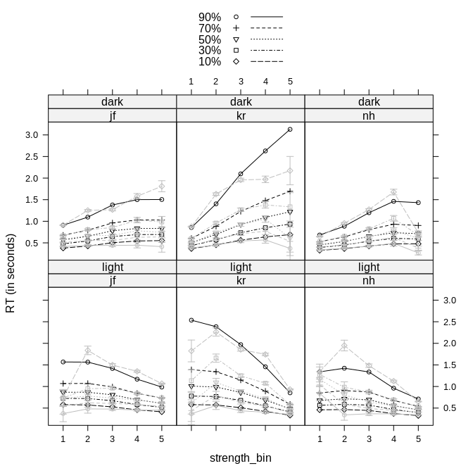

```r
p1 <- xyplot(rt ~ strength_bin|id+response, agg2_rr98_response, group = quantile, type = "b",
             auto.key = list(lines = TRUE), ylab = "RT (in seconds)",
             subset = instruction == "accuracy", layout = c(3,2), col = "grey")
p1e <- segplot(strength_bin ~ upper+lower|id+response, agg2_rr98_response,
               auto.key = list(lines = TRUE), ylab = "Proportion of 'dark' responses",
               col = "grey", horizontal = FALSE, segments.fun = panel.arrows,
               draw.bands = FALSE, angle = 90, length = 0.05, ends = "both",
               subset = instruction == "accuracy")
p2 <- xyplot(rt ~ strength_bin|id + response, lba_separate_pred, group = quantiles, type = "b",
             auto.key = list(lines = TRUE), ylab = "RT (in seconds)",
             subset = instruction == "accuracy", scales = list(y = list(limits = c(0.1, 3.3))))
p2 + as.layer(p1) + as.layer(p1e)
```

These two plots show not only the central tendency, but the other quantiles are quite well described.

# Comparing Model Fit

Finally, we graphically compare the fit of the two models. Here we can see that while the LBA seems to provide a slightly better fit (as indicated by the lower negative log-likelihoods), the diffusion model seems to somewhat better recover some of the trends in the data.

## Predicted Response Rates

We again first consider the predicted response rates (in black) for the two models.

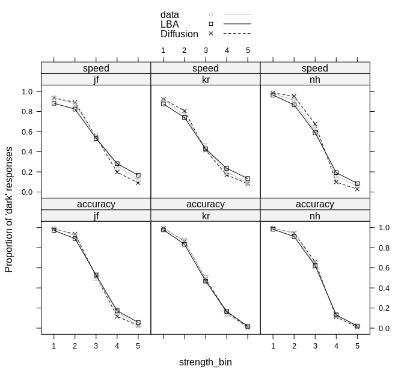

```r
key <- simpleKey(text = c("data", "LBA", "Diffusion"), lines = TRUE)
key$lines$col <- c("grey", "black", "black")
key$lines$lty <- c(1, 1, 2)
key$points$col <- c("grey", "black", "black")
key$points$pch <- c(1, 0, 4)

p1 <- xyplot(mean ~ strength_bin|id + instruction, agg_rr98_bin, type = "b", auto.key =
               list(lines = TRUE), ylab = "Proportion of 'dark' responses", col = "grey")
p2 <- segplot(strength_bin ~ upper+lower|id + instruction, agg_rr98_bin,
              auto.key = list(lines = TRUE), ylab = "Proportion of 'dark' responses",
              col = "grey", horizontal = FALSE, segments.fun = panel.arrows,
              draw.bands = FALSE, angle = 90, length = 0.05, ends = "both")
p3 <- xyplot(resp_prop ~ strength_bin|id + instruction, lba_pars_separate_l, type = "b",
             auto.key = list(lines = TRUE), ylab = "Proportion of 'dark' responses",
             col = "black", pch = 0)
p4 <- xyplot(resp_prop ~ strength_bin|id + instruction, pars_separate_l, type = "b",
             auto.key = list(lines = TRUE), ylab = "Proportion of 'dark' responses",
             col = "black", lty = 2, key = key, pch=4)
p4 + as.layer(p2) + as.layer(p1) + as.layer(p3)
```

When comparing the fit of the two models like this, it shows that both models make very similar predictions for the predicted response rates. It is difficult to see huge differences between the models.

## Predicted Median RTs

Next, we also compare the two accounts for the median. As before, data is shown in grey and we begin with a plot for the speed condition, separated by response.

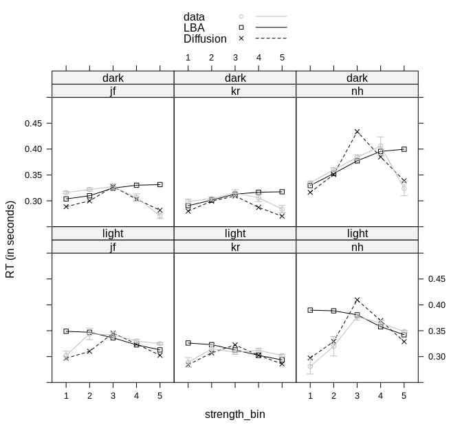

```r
p1 <- xyplot(rt ~ strength_bin|id+response, agg2_rr98_response, type = "b",
             auto.key = list(lines = TRUE), ylab = "RT (in seconds)",
             subset = instruction == "speed" & quantile == "50%",
             layout = c(3,2), col = "grey")
p1e <- segplot(strength_bin ~ upper+lower|id+response, agg2_rr98_response,
               auto.key = list(lines = TRUE), ylab = "Proportion of 'dark' responses",
               col = "grey", horizontal = FALSE, segments.fun = panel.arrows,
               draw.bands = FALSE, angle = 90, length = 0.05, ends = "both",
               subset = instruction == "speed" & quantile == "50%", layout = c(3,2))
p2 <- xyplot(rt ~ strength_bin|id + response, lba_separate_pred, type = "b",
             auto.key = list(lines = TRUE), ylab = "RT (in seconds)",
             subset = instruction == "speed" & quantiles == "50%",
             scales = list(y = list(limits = c(0.25, 0.5))), pch = 0)
p3 <- xyplot(rt ~ strength_bin|id + response, separate_pred, type = "b",
             auto.key = list(lines = TRUE), ylab = "RT (in seconds)",
             subset = instruction == "speed" & quantiles == "50%",
             scales = list(y = list(limits = c(0.25, 0.5))),
             col = "black", lty = 2, key = key, pch=4)

p3 + as.layer(p2) + as.layer(p1) + as.layer(p1e)
```

This plot suggests that the diffusion model is better able to predict changes in the median RTs in the speed condition across strength bins than the LBA. While this leads to obvious misfit in certain cases (`dark` responses for `nh`) it appears to provide a generally better recovery of the patterns in the data.

Next shows the same plot for the accuracy condition.

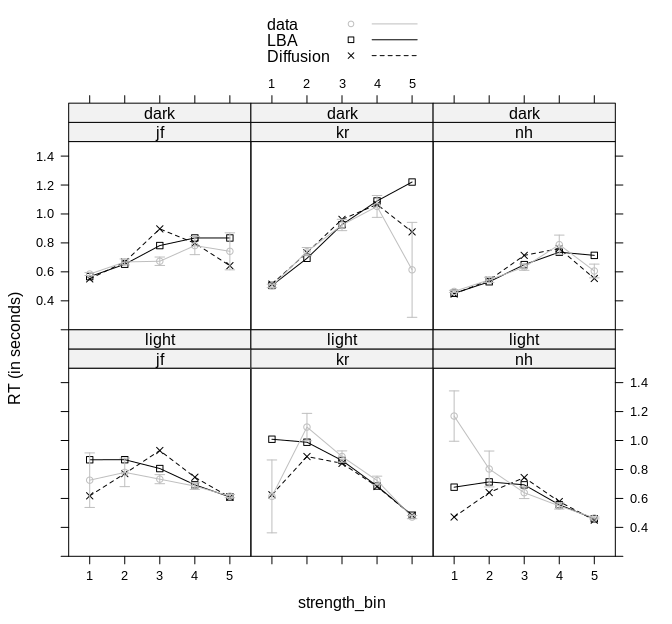

```r
p1 <- xyplot(rt ~ strength_bin|id+response, agg2_rr98_response, type = "b",
             auto.key = list(lines = TRUE), ylab = "RT (in seconds)",
             subset = instruction == "accuracy" & quantile == "50%",
             layout = c(3,2), col = "grey")
p1e <- segplot(strength_bin ~ upper+lower|id+response, agg2_rr98_response,
               auto.key = list(lines = TRUE), ylab = "Proportion of 'dark' responses",
               col = "grey", horizontal = FALSE, segments.fun = panel.arrows,
               draw.bands = FALSE, angle = 90, length = 0.05, ends = "both",
               subset = instruction == "accuracy" & quantile == "50%", layout = c(3,2))
p2 <- xyplot(rt ~ strength_bin|id + response, lba_separate_pred, type = "b",
             auto.key = list(lines = TRUE), ylab = "RT (in seconds)",
             subset = instruction == "accuracy" & quantiles == "50%",
             pch = 0)
p3 <- xyplot(rt ~ strength_bin|id + response, separate_pred, type = "b",
             auto.key = list(lines = TRUE), ylab = "RT (in seconds)",
             subset = instruction == "accuracy" & quantiles == "50%",
             scales = list(y = list(limits = c(0.2, 1.5))),
             col = "black", lty = 2, key = key, pch=4)

p3 + as.layer(p2) + as.layer(p1) + as.layer(p1e)
```

Here we see the same observation as for the speed condition. Considerable changes in median RT across strength bins are better captured by the diffusion model than the LBA. This leads to the situation that in most cases the diffusion model can make more accurate prediction for conditions with low numbers of trials.

# References

- Ratcliff, R., & Rouder, J. N. (1998). Modeling Response Times for Two-Choice Decisions. *Psychological Science*, 9(5), 347–356. http://doi.org/10.1111/1467-9280.00067